# Jakość pracy i wykluczenie na europejskich rynkach pracy

Izabela Reszka, Piotr Wiśniewski, Klaudia Woźniak

2025-11-25

# 1 Cel projektu

Celem projektu jest wielowymiarowa analiza porównawcza kondycji rynków pracy w wybranych gospodarkach świata. Badanie ma na celu skonstruowanie syntetycznego wskaźnika **“Jakości Pracy i Inkluzji Społecznej”**, który pozwoli na stworzenie rankingu krajów pod kątem stabilności zatrudnienia, efektywności wykorzystania kapitału ludzkiego oraz obciążenia pracą.

Dodatkowym celem jest weryfikacja, czy wysoka wydajność gospodarcza (mierzona PKB na pracownika) jest tożsama z wysoką jakością warunków pracy, czy też istnieją modele gospodarcze oparte na wysokiej efektywności, ale niskim bezpieczeństwie socjalnym pracowników. Analiza obejmuje również próby wyodrębnienia (klasteryzacji) grup krajów o podobnych profilach strukturalnych rynku pracy.

## 1.1 Hipotezy badawcze

W projekcie postawiono następujące hipotezy badawcze:

- **H1:** Istnieje wyraźna, dodatnia korelacja między wydajnością pracy (Labour Productivity) a syntetyczną jakością zatrudnienia. Kraje o wysokim nasyceniu technologicznym oferują zazwyczaj stabilniejsze i mniej obciążające czasowo warunki pracy.
- **H2:** Występuje zjawisko “trade-off” (wymienności) między liczbą przepracowanych godzin a wydajnością. Kraje o najdłuższym tygodniowym czasie pracy charakteryzują się niższą wydajnością jednostkową, co wskazuje na ekstensywny, a nie intensywny model rozwoju.
- **H3:** Analiza skupień pozwoli wyodrębnić specyficzny klaster krajów (tzw. “Prekariat Południa/Wschodu”), charakteryzujący się wysokim udziałem młodzieży niepracującej (NEET) oraz wysokim poziomem zatrudnienia wrażliwego, mimo relatywnie przeciętnych wskaźników ogólnego bezrobocia.

## 1.2 Opis projektu (Metodyka)

Badanie opiera się na metodach Wielowymiarowej Analizy Statystycznej (MSA). Jako źródło danych wykorzystano bazy **Międzynarodowej Organizacji Pracy (ILOSTAT)**.

Proces badawczy obejmuje następujące etapy: 1. **Selekcja zmiennych:** Dobór wskaźników diagnostycznych opisujących negatywne (destymulanty) i pozytywne (stymulanty) aspekty rynku pracy. 2. **Normalizacja danych:** Sprowadzenie zmiennych do porównywalności (unitaryzacja zerowana lub standaryzacja) w celu wyeliminowania wpływu różnych jednostek miary (procenty vs. dolary vs. godziny).

## 1.3 Opis zmiennych diagnostycznych

### 1.3.1 1. Zmienne identyfikacyjne i porządkowe

Te kolumny służą do identyfikacji obiektu badania i nie biorą bezpośredniego udziału w obliczeniach rankingowych, ale są kluczowe dla struktury bazy danych.

- **`ref_area` (Reference Area)**
  - **Opis:** Nazwa kraju (jednostki terytorialnej) objętego badaniem.
  - **Zakres:** lista państw i terytoriów zależnych Europy.
- **`time`**
  - **Opis:** Rok, którego dotyczą obserwacje.
  - **Zakres:** Lata 2015–2023 (do analizy przekrojowej zostanie wybrany jeden rok, np. 2022).
- **`sex`**
  - **Opis:** Płeć, której dotyczą dane statystyczne.
  - **Kategorie:** *Female* (Kobiety), *Male* (Mężczyźni), *Total* (Ogółem).
  - **Zastosowanie:** Do budowy głównego rankingu wykorzystane zostaną wiersze z kategorii *Total*.

### 1.3.2 2. Główne zmienne diagnostyczne (Rynek Pracy - ILO)

- **`obs_value_unempl_rate` (Stopa bezrobocia)**
  - **Definicja:** Procentowy udział osób bezrobotnych w ogólnej liczbie ludności aktywnej zawodowo (siły roboczej).
  - **Jednostka:** % (Procent).
  - **Charakter:** **Destymulanta** (wzrost wartości jest niekorzystny).
  - **Interpretacja:** Podstawowa miara braku równowagi na rynku pracy.
- **`obs_value_NEET` (Wskaźnik NEET)**
  - **Definicja:** Odsetek młodzieży niepracującej, niekształcącej się i nieszkolącej zawodowo (*Share of youth not in employment, education or training*).
  - **Jednostka:** % (Procent populacji młodzieżowej).
  - **Charakter:** **Destymulanta**.
  - **Interpretacja:** Mierzy wykluczenie społeczne i strukturalne niewykorzystanie potencjału młodych kadr.
- **`obs_value_PKB` (Wydajność pracy / Labour Productivity)**
  - **Definicja:** Wartość PKB przypadająca na jednego pracującego (*Output per worker*), wyrażona w parytecie siły nabywczej.
  - **Jednostka:** Dolar międzynarodowy
  - **Charakter:** **Stymulanta** (wzrost wartości jest korzystny).
  - **Interpretacja:** Określa poziom rozwoju technologicznego i efektywność gospodarczą kraju.
- **`obs_value_worked_hours` (Całkowity wolumen godzin pracy)**
  - **Definicja:** Łączna liczba godzin przepracowanych w gospodarce przez wszystkich pracujących w ciągu roku/tygodnia.
  - **Jednostka:** Tysiące godzin.
- **`obs_value_informal` (Zatrudnienie w szarej strefie)**
  - **Definicja:** Odsetek pracujących w gospodarce nieformalnej.

### 1.3.3 3. Zmienne kontekstowe (Wolność Gospodarcza - Heritage Foundation)

Zmienne te pochodzą z *Index of Economic Freedom*. Służą do oceny otoczenia instytucjonalnego. W projekcie pełnią rolę zmiennych objaśniających lub referencyjnych.

- **`obs_value_economic_freedom_overall`**
  - **Opis:** Główny, syntetyczny indeks Wolności Gospodarczej. Agreguje wszystkie poniższe sub-indeksy.
  - **Skala:** 0–100 pkt (im więcej, tym większa wolność).
- **`Labor Freedom` (Wolność rynku pracy)**
  - **Opis:** Mierzy ramy prawne dotyczące płacy minimalnej, łatwości zatrudniania i zwalniania pracowników oraz restrykcyjność godzin pracy.
  - **Interpretacja:** Wysoki wynik oznacza bardzo elastyczny rynek (łatwe zwolnienia), niski wynik oznacza rynek mocno regulowany (duża ochrona pracownika).
- **Pozostałe sub-indeksy (wymienione w pliku):**
  - *Rule of Law:* `Property Rights` (Prawa własności), `Judicial Effectiveness` (Efektywność sądów), `Government Integrity` (Uczciwość rządu).
  - *Government Size:* `Tax Burden` (Obciążenia podatkowe), `Government Spending` (Wydatki rządowe), `Fiscal Health` (Zdrowie fiskalne).
  - *Regulatory Efficiency:* `Business Freedom` (Swoboda działalności), `Monetary Freedom` (Stabilność pieniądza).
  - *Open Markets:* `Trade Freedom` (Handel zagraniczny), `Investment Freedom` (Inwestycje), `Financial Freedom` (Sektor finansowy).

## 1.4 Opis plików źródłowych (Przed połączeniem)

Dane zostały pobrane z repozytorium ILOSTAT w postaci osobnych plików CSV dla każdego wskaźnika.

*Proces przygotowania danych (ETL):* Pliki zostały połączone (zmergowane) w jedną bazę danych przy użyciu klucza `Kraj` (Reference Area) + `Rok` (Time), usuwając zbędne kolumny techniczne i ujednolicając nazewnictwo krajów.

# 2 Wstępna analiza danych

## 2.1 Struktura danych oraz podstawowe statystyki

Struktura danych

|  | Typ |
| --- | --- |
| ref_area | factor |
| time | integer |
| sex | factor |
| obs_value_unempl_rate | numeric |
| obs_value_informal | numeric |
| obs_value_worked_hours | numeric |
| obs_value_NEET | numeric |
| obs_value_PKB | numeric |
| obs_value_economic_freedom_overall | numeric |
| Property.Rights | numeric |
| Government.Integrity | numeric |
| Judicial.Effectiveness | numeric |
| Tax.Burden | numeric |
| Government.Spending | numeric |
| Fiscal.Health | numeric |
| Business.Freedom | numeric |
| Labor.Freedom | numeric |
| Monetary.Freedom | numeric |
| Trade.Freedom | numeric |
| Investment.Freedom | numeric |
| Financial.Freedom | numeric |

#### 2.1.0.1 Interpreacja:

W pierwotnym zbiorze danych znajdowało się 21 kolumn zawierających informacje dotyczące państw, lat, płci oraz różnych wskaźników ekonomicznych i społecznych. Funkcja `glimpse(df)` wykazała, że:

- większość kolumn liczbowych była już poprawnie zapisana w formacie numerycznym (`dbl` – double precision numeric),
- zmienne opisowe, takie jak *ref_area* (państwo) oraz *sex* (płeć), były zapisane jako tekst (`chr`).

Aby przygotować dane do dalszych analiz statystycznych i modelowania, wprowadzono jedynie **minimalne i niezbędne zmiany typów danych**:

1. **Kolumnę `ref_area` zmieniono z typu `character` na `factor`**, ponieważ reprezentuje ona zmienną kategoryczną (nazwy państw).
2. **Kolumnę `sex` zmieniono z typu `character` na `factor`**, ponieważ zmienna ta ma skończony zbiór kategorii (Female, Male, Total).
- Wszystkie kolumny liczbowo-wskaźnikowe (`obs_value_*`, wskaźniki ekonomiczne) pozostały w typie `dbl`, który jest domyślnym i odpowiednim typem liczbowym w R.
- Kolumna `time` pozostała w typie `integer`, który jest również poprawny.

W zbiorze **nie było konieczności** konwertowania kolumn `dbl` na `numeric`, ponieważ są one traktowane tak samo przez R.

Struktura danych

| Zmienna | Braki | Średnia | Odchylenie | Min | Mediana | Max |
| --- | --- | --- | --- | --- | --- | --- |
| time | 0 | 2018.964912 | 2.568567 | 2015.000 | 2019.0000 | 2023.000 |
| obs_value_unempl_rate | 2 | 7.724115 | 4.814819 | 0.496 | 6.3165 | 30.694 |
| obs_value_informal | 243 | 7.548680 | 11.638313 | 0.182 | 2.9620 | 61.350 |
| obs_value_worked_hours | 30 | 5921.773632 | 10084.118403 | 77.061 | 2224.2235 | 73636.161 |
| obs_value_NEET | 70 | 11.966129 | 5.782211 | 2.705 | 10.7665 | 35.740 |
| obs_value_PKB | 27 | 98912.209775 | 47262.817155 | 17879.450 | 90021.0200 | 292075.850 |
| obs_value_economic_freedom_overall | 150 | 68.878182 | 6.980637 | 46.800 | 68.5500 | 84.200 |
| Property.Rights | 150 | 72.054546 | 18.148058 | 20.000 | 75.3500 | 100.000 |
| Government.Integrity | 150 | 62.811212 | 20.450042 | 11.100 | 60.3000 | 99.500 |
| Judicial.Effectiveness | 369 | 63.192607 | 18.132576 | 15.500 | 62.1000 | 100.000 |
| Tax.Burden | 150 | 70.393939 | 15.010782 | 37.200 | 72.8000 | 95.000 |
| Government.Spending | 150 | 41.073333 | 19.377258 | 0.000 | 42.3500 | 81.100 |
| Fiscal.Health | 369 | 79.428016 | 20.330036 | 6.100 | 86.1000 | 99.900 |
| Business.Freedom | 150 | 74.930606 | 9.858997 | 45.700 | 75.5000 | 97.400 |
| Labor.Freedom | 150 | 60.157879 | 9.605377 | 42.100 | 60.5000 | 92.100 |
| Monetary.Freedom | 150 | 80.655152 | 5.709365 | 47.400 | 81.7000 | 91.700 |
| Trade.Freedom | 150 | 84.111212 | 4.065083 | 68.000 | 86.0000 | 90.000 |
| Investment.Freedom | 150 | 75.878788 | 13.668969 | 15.000 | 75.0000 | 95.000 |
| Financial.Freedom | 150 | 63.545454 | 13.884379 | 10.000 | 70.0000 | 90.000 |

## 2.2 Identyfikacja braków w danych

### 2.2.1 Wszystkie zmienne

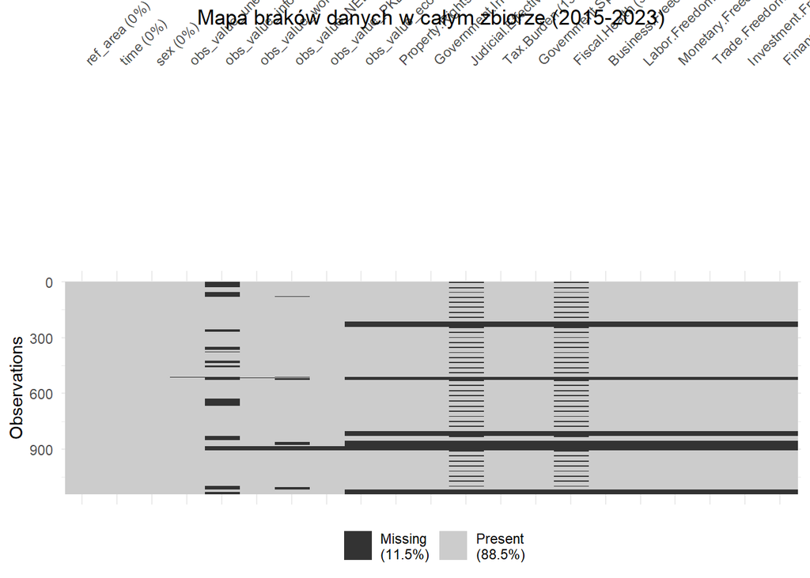

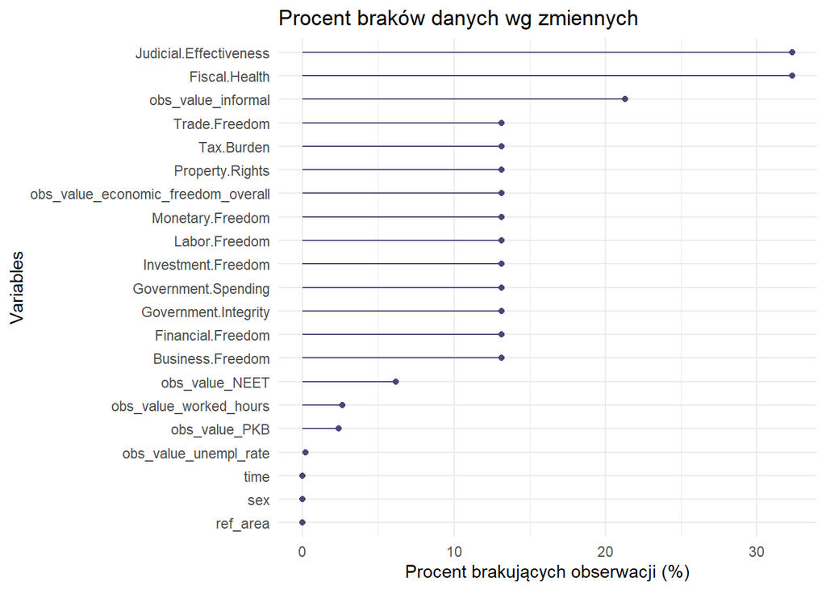

#### 2.2.1.1 Interpretacja analizy braków danych

Przeprowadzona analiza kompletności zbioru danych (z wykorzystaniem funkcji `gg_miss_var`) wykazała istotne zróżnicowanie w dostępności poszczególnych zmiennych. Na podstawie wygenerowanego wykresu można sformułować następujące wnioski:

- **Zmienne o krytycznym poziomie braków (>30%)** Zmienne `Fiscal.Health` oraz `Judicial.Effectiveness` charakteryzują się najwyższym odsetkiem brakujących obserwacji (przekraczającym 30%). Tak wysoki poziom niekompletności dyskwalifikuje je jako główne zmienne diagnostyczne w modelu, ponieważ ich uwzględnienie wymagałoby drastycznego ograniczenia liczby badanych krajów lub zastosowania zaawansowanych metod imputacji, co mogłoby zniekształcić wyniki rankingu.
- **Problematyczna zmienna “Szara strefa” (`obs_value_informal`)** Zmienna dotycząca zatrudnienia w gospodarce nieformalnej wykazuje braki na poziomie ponad 20%. Jest to sygnał, że dane te mogą nie być raportowane systematycznie przez wszystkie kraje.
- **Zmienne kontekstowe (Wolność gospodarcza)** Grupa wskaźników pochodzących z *Heritage Foundation* (m.in. `Government.Spending`, `Tax.Burden`, `Property.Rights`) wykazuje umiarkowany poziom braków (ok. 10-15%). Sugeruje to, że dla części krajów lub lat w badanym okresie (2015-2023) indeks ten nie został obliczony.

**Wysoka jakość kluczowych zmiennych diagnostycznych** Najważniejszym wnioskiem z analizy jest **bardzo wysoka kompletność zmiennych rynku pracy**, które zostały wytypowane do budowy głównego wskaźnika syntetycznego: * `obs_value_unempl_rate` (Stopa bezrobocia) – braki bliskie 0%. * `obs_value_PKB` (Wydajność/PKB) – braki poniżej 5%. * `obs_value_NEET` – braki poniżej 10%.

### 2.2.2 W zależności od kraju

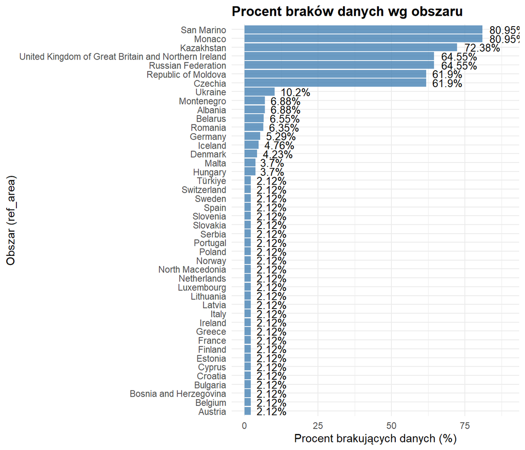

Zbiór danych jest wyraźnie podzielony na dwie grupy: kraje z krytycznymi brakami danych oraz kraje z wysoką kompletnością informacji.

1. **Grupa z krytycznymi brakami (>60%):** Na szczycie znajdują się mikropaństwa (**San Marino, Monako** – ponad 80% braków), co jest typowe w statystyce międzynarodowej. Jednak niepokojąca jest obecność dużych gospodarek w tej grupie: **Wielkiej Brytanii, Rosji czy Czech** (60-65% braków). Tak wysoki odsetek pustych wartości prawdopodobnie wyklucza te kraje z wiarygodnej analizy porównawczej.
2. **Grupa “stabilna” (<7%):** Zdecydowana większość analizowanych krajów (od Czarnogóry w dół) posiada kompletność danych na poziomie powyżej 93%.
3. **Systematyczny błąd (Wartość 2.12%):** Zwraca uwagę fakt, że ogromna liczba państw (od Turcji aż do Austrii) ma identyczny wynik braków: **2.12%**. To nie jest przypadek.
   - **Interpretacja:** Sugeruje to **systematyczny brak danych**, np. jedna konkretna zmienna nie jest raportowana dla całej tej grupy krajów lub brakuje danych za jeden konkretny rok w szeregu czasowym.

## 2.3 Wartości odstające oraz rozkład danych

### 2.3.1 Wykresy skrzypcowe

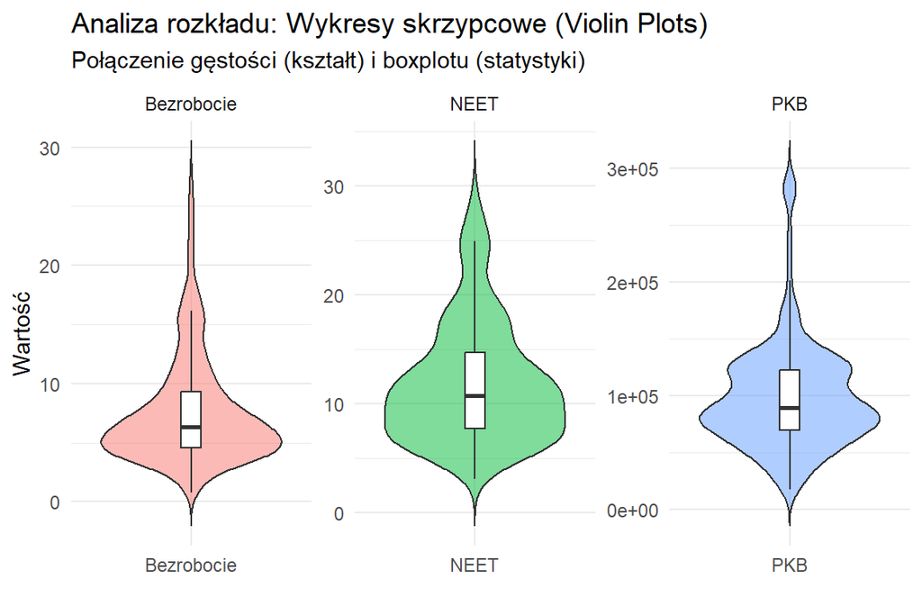

*Interpreacja*:

- **Stopa bezrobocia (`Bezrobocie`)**:
  - **Charakter rozkładu:** Wyraźnie **prawostronnie skośny** (asymetryczny dodatnio).
  - **Koncentracja:** “Brzusiec” skrzypiec znajduje się nisko, co oznacza, że zdecydowana większość badanych krajów charakteryzuje się niską stopą bezrobocia (mediana oscyluje w granicach 5-7%).
  - **Wartości odstające:** Długa, cienka “szyjka” wykresu ciągnąca się w górę wskazuje na występowanie grupy państw o bardzo wysokim bezrobociu (sięgającym 15-30%). Są to klasyczne wartości odstające (outliery), które będą wymagały standaryzacji, aby nie zdominowały rankingu.
- **Wskaźnik NEET (`NEET`)**:
  - **Charakter rozkładu:** Podobnie jak w przypadku bezrobocia, rozkład jest asymetryczny prawostronnie, jednak jest on bardziej “spłaszczony” (bardziej równomierny) niż w przypadku bezrobocia.
  - **Koncentracja:** Mediana przyjmuje wyższe wartości (ok. 10-12%). Rozrzut danych jest znaczny (od ok. 3% do 30%), co sugeruje duże zróżnicowanie w Europie pod względem aktywizacji młodzieży.
- **Wydajność pracy / PKB (`PKB`)**:
  - **Charakter rozkładu:** **Silna asymetria prawostronna**. Jest to najbardziej nierównomierny rozkład ze wszystkich badanych zmiennych.
  - **Koncentracja:** Zdecydowana większość państw skupiona jest w dolnej części wykresu (PKB < 100 tys.).
  - **Wartości ekstremalne:** Bardzo długa “szyjka” wskazuje na obecność “liderów wydajności” których wyniki drastycznie odbiegają od średniej europejskiej.

**Wnioski metodyczne dla budowy rankingu:** Wszystkie trzy zmienne diagnostyczne charakteryzują się brakiem rozkładu normalnego i występowaniem silnej asymetrii prawostronnej. Oznacza to, że: konieczna jest normalizacja zmiennych aby sprowadzić je do porównywalnej skali i zniwelować wpływ wartości odstających (szczególnie w przypadku PKB) na finalny wynik.

## 2.4 Korelacja zmiennych kluczowych

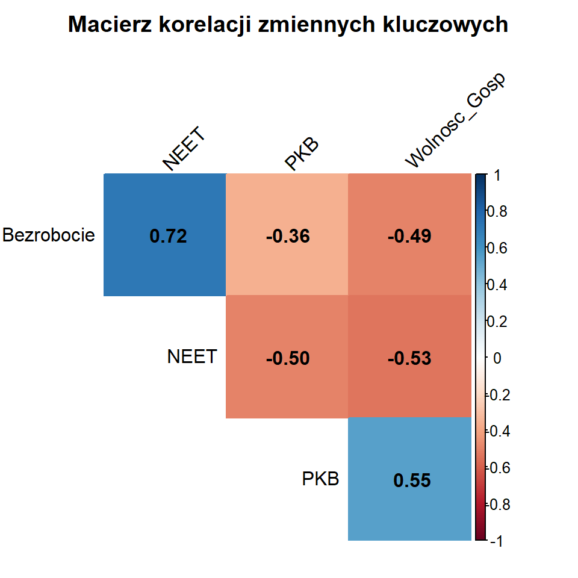

*Interpreacja*:

W celu zbadania siły i kierunku współzależności między potencjalnymi zmiennymi diagnostycznymi (Bezrobocie, NEET, PKB) oraz zmienną kontekstową (Wolność Gospodarcza), wyznaczono macierz korelacji liniowej Pearsona. Analiza wykresu (mapy ciepła) pozwala na sformułowanie następujących wniosków:

**1. Silna synergia zmiennych negatywnych (Bezrobocie i NEET)**

- Obserwuje się **silną dodatnią korelację** (ciemnoniebieskie pole) między stopą bezrobocia a wskaźnikiem NEET. Jest to zależność oczekiwana i logiczna – wzrost bezrobocia w populacji ogólnej zazwyczaj pociąga za sobą wzrost wykluczenia wśród młodzieży. Mimo silnego powiązania, współczynnik korelacji nie osiąga poziomu krytycznego (powyżej 0,9), co oznacza, że zmienne te nie duplikują w pełni niesionej informacji.

**2. Odwrotna relacja między wydajnością (PKB) a problemami społecznymi**

**3. Rola Wolności Gospodarczej (`Wolnosc_Gosp`)**

- Wskaźnik ten jest **dodatnio skorelowany z PKB** (niebieskie pole) i ujemnie z bezrobociem (czerwone pole). Potwierdza to hipotezę, że kraje o wyższym poziomie wolności gospodarczej (lepsze instytucje, ochrona własności) osiągają zazwyczaj wyższą wydajność pracy i lepszą sytuację na rynku pracy.

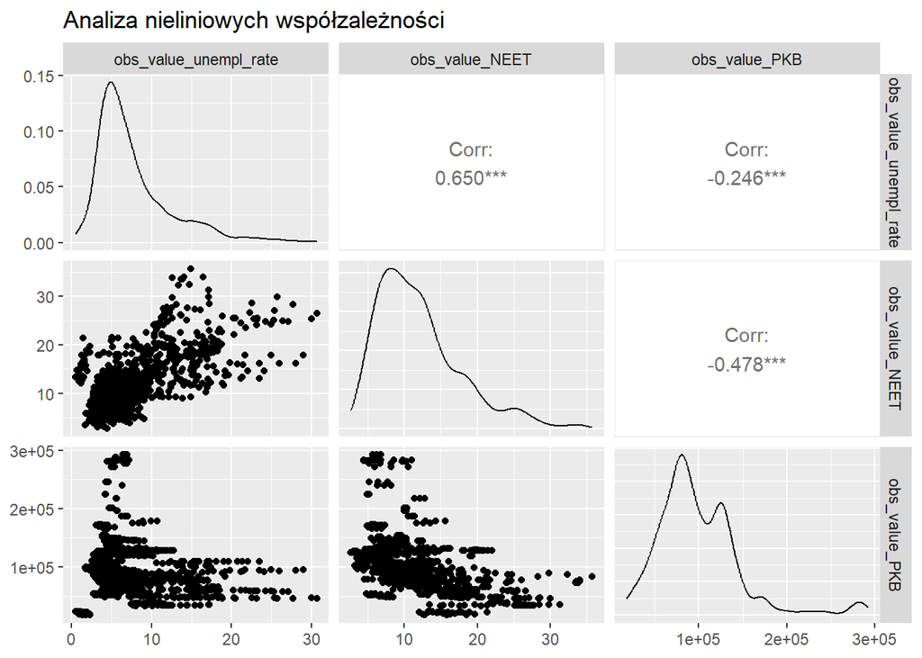

#### 2.4.0.1 1. Wykres braków danych (Bar Plot)

Ten wykres ujawnia **krytyczny podział jakości danych** w Twoim zbiorze:

- **Grupa do odrzucenia (>60% braków):** Kraje takie jak **San Marino, Monako, UK, Rosja, Mołdawia i Czechy** mają drastycznie wysoki odsetek braków danych (od 62% do 81%). Wnioskowanie statystyczne na ich podstawie będzie obarczone ogromnym błędem. Zaleca się usunięcie tych obserwacji ze zbioru.
- **Systematyczny brak (2.12%):** Ogromna grupa państw (od Turcji do Austrii) posiada identyczny odsetek braków wynoszący **2.12%**. Sugeruje to **błąd strukturalny** – prawdopodobnie dla wszystkich tych krajów brakuje danych z jednego konkretnego roku lub jednej specyficznej zmiennej (kolumny).
- **Wniosek:** Zbiór jest niejednorodny. Należy usunąć kraje z góry wykresu i sprawdzić, która zmienna generuje stały błąd 2.12% dla reszty.

#### 2.4.0.2 2. Analiza współzależności (Macierz korelacji / Scatterplots)

Wykres przedstawia relacje między stopą bezrobocia (`unempl_rate`), wskaźnikiem NEET i PKB (`PKB`).

- **Silna dodatnia korelacja (0.650***) między Bezrobociem a NEET:** Jest to zależność oczekiwana i liniowa. Wzrost stopy bezrobocia pociąga za sobą wyraźny wzrost odsetka młodzieży nieuczącej się i niepracującej. Wykres punktowy (lewy środkowy panel) pokazuje jednak dużą wariancję – przy tym samym bezrobociu wskaźnik NEET może być różny, co zależy od polityki socjalnej danego kraju.
- **Ujemny wpływ PKB na problemy społeczne:** Zamożność kraju (PKB) koreluje ujemnie z problemami rynku pracy.
  - Silniejszy związek widać przy **NEET (-0.478***)**: Wyższe PKB skuteczniej “chroni” przed zjawiskiem NEET niż przed samym bezrobociem.
  - Słabszy związek przy **Bezrobociu (-0.246***)**: Samo wysokie PKB nie gwarantuje niskiego bezrobocia (zależność jest słaba).
- **Nieliniowość i rozkłady (Przekątna i doły):**
  - **Rozkład PKB (prawy dolny róg)** jest **bimodalny** (ma dwa “garby”). Wskazuje to na istnienie dwóch klastrów krajów w zbiorze: grupy państw “biedniejszych” i grupy “bogatszych”.
  - Wykresy punktowe z PKB (dolny rząd) mają kształt litery “L” (hiperboliczny). Oznacza to, że po przekroczeniu pewnego progu zamożności, wskaźniki NEET i bezrobocia stabilizują się na niskim poziomie, ale w krajach biedniejszych ich rozrzut jest ogromny.

## 2.5 Czyszczenie braków danych (Cleaning) oraz uzupełnianie

```
## [1] 37 19
```

```
## # A tibble: 18 × 2
##    Zmienna                            CV_proc
##    <chr>                                <dbl>
##  1 Trade.Freedom                         3.09
##  2 Monetary.Freedom                      6.11
##  3 obs_value_economic_freedom_overall    9.90
##  4 Business.Freedom                     12.7
##  5 Labor.Freedom                        16.4
##  6 Investment.Freedom                   18.1
##  7 Fiscal.Health                        18.4
##  8 Property.Rights                      20.1
##  9 Tax.Burden                           20.7
## 10 Financial.Freedom                    22.5
## 11 Judicial.Effectiveness               25.4
## 12 Government.Integrity                 31.8
## 13 Government.Spending                  45.4
## 14 obs_value_NEET                       46.1
## 15 obs_value_PKB                        47.9
## 16 obs_value_unempl_rate                52.6
## 17 obs_value_informal                  138.
## 18 obs_value_worked_hours              140.
```

# 3 Metoda Hellwiga

```r
# 6. Budowa taksonomicznego miernika rozwoju (TMR)
# Źródło: [cite: 875-879]
d_mean <- mean(dist_euclid)
d_sd <- sd(dist_euclid)
d0 <- d_mean + 2 * d_sd

Hellwig_index <- 1 - (dist_euclid / d0)
Hellwig_index[Hellwig_index < 0] <- 0  # wartości ujemne zastępujemy 0

# 7. Tworzenie rankingu
ranking <- data.frame(
  voivodship = df_clean$ref_area,
  H = Hellwig_index
)

ranking <- ranking[order(-ranking$H), ]

print(head(ranking))
```

```
##     voivodship         H
## 21  Luxembourg 0.9023007
## 17     Ireland 0.7130000
## 26      Norway 0.6773818
## 35 Switzerland 0.5899953
## 4      Belgium 0.5795219
## 9      Denmark 0.5735038
```

```r
# 8. Wyznaczenie klas rozwoju
H_mean <- mean(ranking$H)
H_sd   <- sd(ranking$H)

ranking$category <- cut(
  ranking$H,
  breaks = c(-Inf, H_mean - H_sd, H_mean, H_mean + H_sd, Inf),
  labels = c("niski", "średni", "wysoki", "bardzo wysoki"),
  right = TRUE
)

print(ranking)
```

```
##                voivodship          H      category
## 21             Luxembourg 0.90230073 bardzo wysoki
## 17                Ireland 0.71300004 bardzo wysoki
## 26                 Norway 0.67738184 bardzo wysoki
## 35            Switzerland 0.58999533        wysoki
## 4                 Belgium 0.57952190        wysoki
## 9                 Denmark 0.57350376        wysoki
## 24            Netherlands 0.54467415        wysoki
## 13                Germany 0.53865090        wysoki
## 2                 Austria 0.53268221        wysoki
## 34                 Sweden 0.52581181        wysoki
## 16                Iceland 0.51175146        wysoki
## 11                Finland 0.51155453        wysoki
## 22                  Malta 0.47670289        wysoki
## 12                 France 0.47611729        wysoki
```

[output cut: 23 more lines]

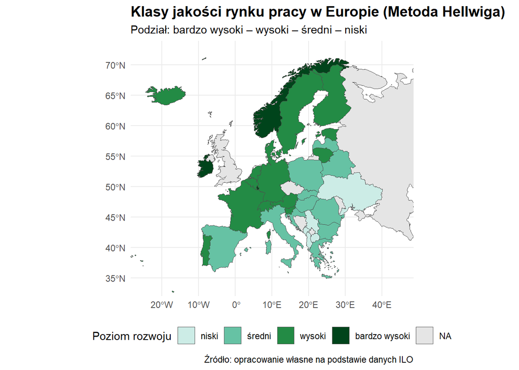

```r
# Wczytanie bibliotek do mapowania (zgodnie z [cite: 513-515] + rnaturalearth jako źródło mapy)
library(sf)
library(ggplot2)
library(dplyr)
library(stringi)
library(rnaturalearth) # Zamiast wczytywać plik .shp z dysku

# 1. Pobranie mapy Europy (zamiast st_read("voivodeships.shp"))
# To jest odpowiednik wczytania pliku kształtów [cite: 517-518]
europe_map <- ne_countries(scale = "medium", returnclass = "sf", continent = "Europe")

# 2. Czyszczenie nazw krajów (zgodnie z [cite: 524-525])
# Używamy stringi, aby ujednolicić nazwy (małe litery, brak znaków specjalnych)
europe_map$name_clean <- tolower(stri_trans_general(europe_map$name, "Latin-ASCII"))
ranking$kraj_clean <- tolower(stri_trans_general(ranking$voivodship, "Latin-ASCII")) # voivodship to u nas nazwa kraju

# Uwaga: Nazwy krajów w mapie mogą być po angielsku (np. "germany"), a w Twoich danych inaczej.
# W analizie "na sztywno" często trzeba ręcznie poprawić różnice, ale tu stosujemy ogólną metodę.

# 3. Połączenie danych (zgodnie z [cite: 527-528])
map_data <- europe_map %>%
  left_join(ranking, by = c("name_clean" = "kraj_clean"))

# 4. Wizualizacja mapy (zgodnie z [cite: 530-550])
ggplot(map_data) +
  geom_sf(aes(fill = category), color = "grey30", size = 0.3) + # [cite: 531]
  scale_fill_manual(
    values = c(
      "bardzo wysoki" = "#00441b",
      "wysoki"        = "#238b45",
      "średni"        = "#66c2a4",
      "niski"         = "#ccece6"
    ),
    name = "Poziom rozwoju",
    na.value = "grey90" # Kolor dla krajów bez danych (np. spoza analizy)
  ) + # [cite: 532-540]
  labs(
    title = "Klasy jakości rynku pracy w Europie (Metoda Hellwiga)",
    subtitle = "Podział: bardzo wysoki – wysoki – średni – niski",
    caption = "Źródło: opracowanie własne na podstawie danych ILO"
  ) + # [cite: 541-545]
  theme_minimal() + # [cite: 546]
  theme(
    plot.title    = element_text(face = "bold", size = 14),
    legend.position = "bottom"
  ) + # [cite: 547-549]
  coord_sf(xlim = c(-25, 45), ylim = c(34, 72)) # Ograniczenie widoku do Europy
```

## 3.1 Metoda CRITIC

```r
# --- ETAP: WAGI CRITIC ---

# 1. Odchylenia standardowe i macierz korelacji [cite: 68, 70]
sigma <- apply(data_norm_z, 2, sd, na.rm = TRUE)
R <- cor(data_norm_z, use = "complete.obs")

# 2. Wskaźnik kontrastu i wagi [cite: 74-76]
C <- sigma * apply(1 - R, 1, sum)
weights_critic <- C / sum(C)

print("Wagi CRITIC:")
```

```
## [1] "Wagi CRITIC:"
```

```r
print(weights_critic)
```

```
##    unempl      neet  informal       pkb
## 0.2428032 0.1920979 0.2690410 0.2960578
```

```r
# 3. Ważenie danych [cite: 77]
df_weighted_critic <- sweep(data_norm_z, 2, weights_critic, `*`)

# 4. Hellwig dla danych ważonych (CRITIC) [cite: 452, 458]
pattern_c <- apply(df_weighted_critic, 2, max)
dist_critic <- sqrt(rowSums((df_weighted_critic - matrix(pattern_c, nrow = nrow(df_weighted_critic), ncol = ncol(df_weighted_critic), byrow = TRUE))^2))

d0_c <- mean(dist_critic) + 2 * sd(dist_critic)
TMR_critic <- 1 - (dist_critic / d0_c)
TMR_critic[TMR_critic < 0] <- 0

ranking_critic <- data.frame(
  Kraj = df_clean$ref_area,  # <-- TU JEST ZMIANA: bierzemy nazwy bezpośrednio z danych
  H_CRITIC = TMR_critic
) %>%
  arrange(desc(H_CRITIC))

print(head(ranking_critic))
```

```
##          Kraj  H_CRITIC
## 1  Luxembourg 0.9157515
## 2     Ireland 0.7160630
## 3      Norway 0.6495999
## 4 Switzerland 0.5615101
## 5     Belgium 0.5579209
## 6     Denmark 0.5388749
```

## 3.2 Metoda Entropii

```r
# --- ETAP: WAGI ENTROPII ---

# 1. Przesunięcie do wartości dodatnich [cite: 93]
data_pos <- data_norm_z - apply(data_norm_z, 2, min) + 1e-6

# 2. Udziały (p_ij) [cite: 95]
p <- sweep(data_pos, 2, colSums(data_pos), FUN = "/")
p[p <= 0] <- 1e-12 # Zabezpieczenie przed log(0)

# 3. Entropia (E) [cite: 102, 105]
n <- nrow(data_pos)
k_const <- 1 / log(n)
E <- -k_const * colSums(p * log(p))

# 4. Dywersyfikacja i wagi [cite: 107, 109]
d_div <- 1 - E
weights_entropy <- d_div / sum(d_div)

print("Wagi Entropii:")
```

```
## [1] "Wagi Entropii:"
```

```r
print(weights_entropy)
```

```
##    unempl      neet  informal       pkb
## 0.3045037 0.2852237 0.1132988 0.2969738
```

```r
# 5. Ważenie danych i Hellwig (Entropia) [cite: 110]
df_weighted_entropy <- sweep(data_norm_z, 2, weights_entropy, `*`)

pattern_e <- apply(df_weighted_entropy, 2, max)
dist_entropy <- sqrt(rowSums((df_weighted_entropy - matrix(pattern_e, nrow = nrow(df_weighted_entropy), ncol = ncol(df_weighted_entropy), byrow = TRUE))^2))

d0_e <- mean(dist_entropy) + 2 * sd(dist_entropy)
TMR_entropy <- 1 - (dist_entropy / d0_e)
TMR_entropy[TMR_entropy < 0] <- 0


ranking_entropy <- data.frame(
  Kraj = df_clean$ref_area,
  H_ENTROPIA = TMR_entropy
) %>%
  arrange(desc(H_ENTROPIA))

print(head(ranking_entropy))
```

```
##          Kraj H_ENTROPIA
## 1  Luxembourg  0.9004022
## 2     Ireland  0.7004825
## 3      Norway  0.6605224
## 4 Switzerland  0.5683628
## 5     Belgium  0.5579556
## 6     Denmark  0.5518937
```

```r
# --- FUNKCJA POMOCNICZA: Obliczanie TMR Hellwiga ---
# Przyjmuje: macierz danych (już zważoną!)
calc_hellwig_tmr <- function(data_matrix) {
  # 1. Wzorzec (zawsze MAX, bo mamy same stymulanty)
  # [cite: 254-255] (źródło 2)
  pattern <- apply(data_matrix, 2, max)

  # 2. Odległość od wzorca (Euklidesowa)
  # [cite: 261] (źródło 2)
  dists <- apply(data_matrix, 1, function(x) sqrt(sum((x - pattern)^2)))

  # 3. Normalizacja miary
  # [cite: 267] (źródło 2)
  d0 <- mean(dists) + 2 * sd(dists)
  tmr <- 1 - (dists / d0)
  tmr[tmr < 0] <- 0 # Korekta ujemnych [cite: 275] (źródło 2)

  return(tmr)
}

# =========================================================
# SCENARIUSZ 1: WAGI RÓWNE (Equal Weights)
# =========================================================
# Metoda najczęściej stosowana, neutralna [cite: 44-48] (źródło 1)
m <- ncol(data_norm_z)
w_equal <- rep(1/m, m)

# Ważenie danych
df_eq_weighted <- sweep(data_norm_z, 2, w_equal, `*`) # [cite: 50] (źródło 1)

# Obliczenie TMR
tmr_eq <- calc_hellwig_tmr(df_eq_weighted)

# =========================================================
# SCENARIUSZ 2: METODA CRITIC (Correlation & Variation)
# =========================================================
# Metoda uwzględniająca zmienność i korelację [cite: 65] (źródło 1)

# 1. Odchylenia standardowe
sigma <- apply(data_norm_z, 2, sd, na.rm = TRUE) # [cite: 68] (źródło 1)

# 2. Macierz korelacji
R <- cor(data_norm_z, use = "complete.obs") # [cite: 70] (źródło 1)

# 3. Wskaźnik kontrastu i wagi
C <- sigma * apply(1 - R, 1, sum) # [cite: 72] (źródło 1)
w_critic <- C / sum(C) # [cite: 76] (źródło 1)

print("Wagi CRITIC:")
```

```
## [1] "Wagi CRITIC:"
```

```r
print(w_critic)
```

```
##    unempl      neet  informal       pkb
## 0.2428032 0.1920979 0.2690410 0.2960578
```

```r
# Ważenie danych
df_critic_weighted <- sweep(data_norm_z, 2, w_critic, `*`) # [cite: 77] (źródło 1)

# Obliczenie TMR
tmr_critic <- calc_hellwig_tmr(df_critic_weighted)

# =========================================================
# SCENARIUSZ 3: METODA ENTROPII (Shannon Entropy)
# =========================================================
# Metoda premiująca zmienne o dużym zróżnicowaniu [cite: 86] (źródło 1)

# 1. Przesunięcie do wartości dodatnich (wymagane do logarytmu)
data_pos <- data_norm_z - apply(data_norm_z, 2, min) + 1e-6 # [cite: 93] (źródło 1)

# 2. Normalizacja udziałów
p <- sweep(data_pos, 2, colSums(data_pos), FUN = "/") # [cite: 95] (źródło 1)
p[p <= 0] <- 1e-12 # Zabezpieczenie przed log(0) [cite: 104] (źródło 1)

# 3. Entropia i dywersyfikacja
k_const <- 1 / log(nrow(data_pos)) # [cite: 98] (źródło 1)
E <- -k_const * colSums(p * log(p)) # [cite: 105] (źródło 1)
d_div <- 1 - E # [cite: 107] (źródło 1)

# 4. Wagi
w_entropy <- d_div / sum(d_div) # [cite: 109] (źródło 1)

print("Wagi Entropii:")
```

```
## [1] "Wagi Entropii:"
```

```r
print(w_entropy)
```

```
##    unempl      neet  informal       pkb
## 0.3045037 0.2852237 0.1132988 0.2969738
```

```r
# Ważenie danych
df_entropy_weighted <- sweep(data_norm_z, 2, w_entropy, `*`) # [cite: 110] (źródło 1)

# Obliczenie TMR
tmr_entropy <- calc_hellwig_tmr(df_entropy_weighted)

# =========================================================
# ZESTAWIENIE WYNIKÓW (TABELA PORÓWNAWCZA)
# =========================================================

# Tworzymy główną tabelę wyników
# TUTAJ ZMIANA: Używamy df_clean$ref_area zamiast rownames, aby mieć nazwy krajów
comparison_table <- data.frame(
  Kraj = df_clean$ref_area,
  TMR_Rowne = round(tmr_eq, 4),
  Rank_Rowne = rank(-tmr_eq),     # Ranking (1 = najlepszy)
  TMR_Critic = round(tmr_critic, 4),
  Rank_Critic = rank(-tmr_critic),
  TMR_Entropia = round(tmr_entropy, 4),
  Rank_Entropia = rank(-tmr_entropy)
) %>%
  arrange(Rank_Rowne) # Sortujemy wg standardowego Hellwiga

# Wyświetlenie tabeli
print(head(comparison_table, 10))
```

```
##           Kraj TMR_Rowne Rank_Rowne TMR_Critic Rank_Critic TMR_Entropia
## 1   Luxembourg    0.9023          1     0.9158           1       0.9004
## 2      Ireland    0.7130          2     0.7161           2       0.7005
## 3       Norway    0.6774          3     0.6496           3       0.6605
## 4  Switzerland    0.5900          4     0.5615           4       0.5684
## 5      Belgium    0.5795          5     0.5579           5       0.5580
## 6      Denmark    0.5735          6     0.5389           6       0.5519
## 7  Netherlands    0.5447          7     0.5017           8       0.5213
## 8      Germany    0.5387          8     0.4976           9       0.5146
## 9      Austria    0.5327          9     0.5099           7       0.5093
## 10      Sweden    0.5258         10     0.4901          10       0.5009
##    Rank_Entropia
## 1              1
## 2              2
## 3              3
## 4              4
## 5              5
## 6              6
## 7              7
## 8              8
## 9              9
## 10            10
```

```r
# =========================================================
# MIARY PODOBIEŃSTWA RANKINGÓW
# =========================================================
# Analiza wrażliwości - porównanie rankingów dla różnych zestawów wag [cite: 126] (źródło 1)
# Obliczamy współczynnik korelacji rangowej Spearmana  (źródło 1)

cor_matrix <- cor(comparison_table[, c("TMR_Rowne", "TMR_Critic", "TMR_Entropia")],
                  method = "spearman")

print("Korelacja rangowa (Spearman) między metodami:")
```

```
## [1] "Korelacja rangowa (Spearman) między metodami:"
```

```r
print(cor_matrix)
```

```
##              TMR_Rowne TMR_Critic TMR_Entropia
## TMR_Rowne    1.0000000  0.9840555    0.9931836
## TMR_Critic   0.9840555  1.0000000    0.9810337
## TMR_Entropia 0.9931836  0.9810337    1.0000000
```

# 4 Analiza skupień

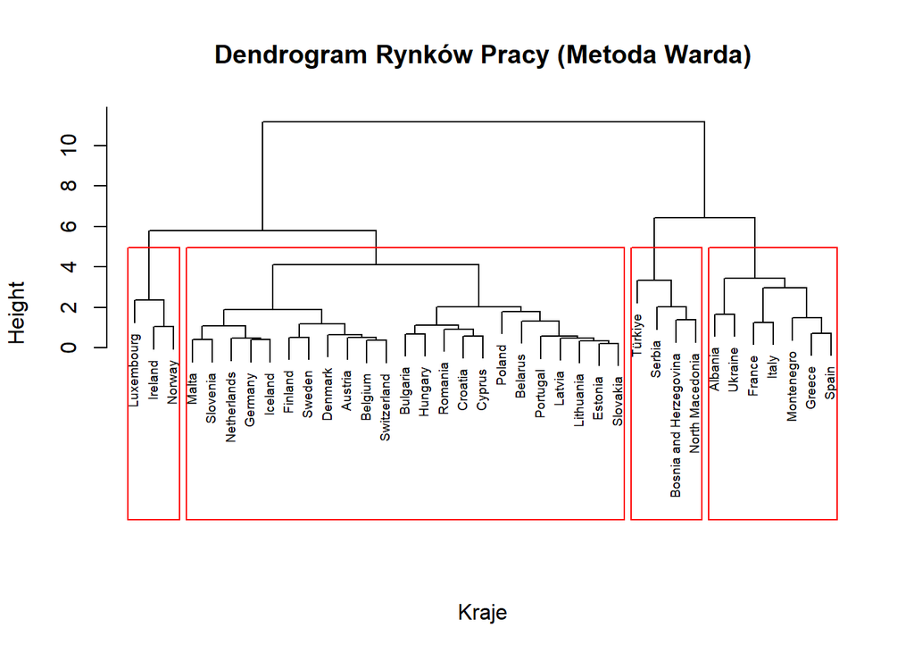

```r
# --- ANALIZA SKUPIEŃ: METODY HIERARCHICZNE ---

# 1. Macierz odległości Euklidesowej
# Korzystamy z data_norm_z, którą stworzyłeś przy Hellwigu
# Źródło: Lab 7 [cite: 796]
dist_euclid <- dist(data_norm_z, method = "euclidean")

# 2. Grupowanie metodą Warda
# Źródło: Lab 7 [cite: 802]
hc_ward <- hclust(dist_euclid, method = "ward.D2")

# 3. Wykres Dendrogramu
# Używamy df_clean$ref_area do etykiet, żeby mieć pewność, że są nazwy krajów
# Źródło: Lab 7 [cite: 804-806]
plot(hc_ward,
     labels = df_clean$ref_area,
     main = "Dendrogram Rynków Pracy (Metoda Warda)",
     xlab = "Kraje",
     sub = "",
     cex = 0.6) # Mniejsza czcionka dla czytelności

# Rysujemy prostokąty dla sugerowanej liczby klastrów (np. k=4)
# Źródło: Lab 7 [cite: 814]
rect.hclust(hc_ward, k = 4, border = "red")
```

## 4.1 Metoda łokcia

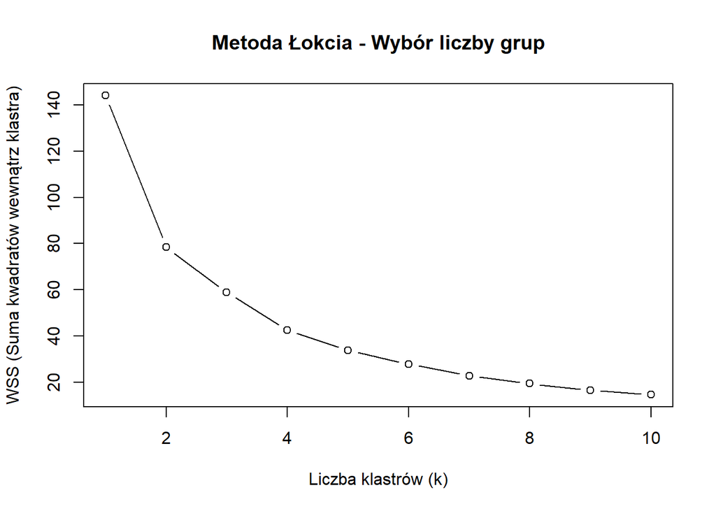

```r
# --- METODA ŁOKCIA (ELBOW METHOD) ---
# Źródło: Lab 8 [cite: 179-183]

wss <- numeric(10)
for (k in 1:10) {
  set.seed(123)
  # Używamy data_norm_z
  km <- kmeans(data_norm_z, centers = k, nstart = 25)
  wss[k] <- km$tot.withinss
}

# Wykres osypiska
# Źródło: Lab 8 [cite: 185-188]
plot(1:10, wss, type = "b",
     xlab = "Liczba klastrów (k)",
     ylab = "WSS (Suma kwadratów wewnątrz klastra)",
     main = "Metoda Łokcia - Wybór liczby grup")
```

## 4.2 Metoda k-średnich

```r
# --- METODA K-ŚREDNICH (K-MEANS) ---

# 1. Uruchomienie algorytmu
# Przyjmujemy k=4 (możesz zmienić tę wartość po obejrzeniu wykresu łokcia)
# Źródło: Lab 8 [cite: 26]
set.seed(123)
k_final <- 4
km_res <- kmeans(data_norm_z, centers = k_final, nstart = 25)

# 2. Przypisanie grup do danych oryginalnych
# Źródło: Lab 8 [cite: 75]
df_clean$Cluster <- factor(km_res$cluster)

# 3. Profilowanie klastrów (średnie wartości zmiennych w grupach)
# UWAGA: Tutaj używamy df_clean i oryginalnych nazw kolumn (nie _s),
# żeby widzieć prawdziwe wartości (np. % bezrobocia), a nie Z-score.
# Źródło: Lab 8 [cite: 155]
profiles <- aggregate(cbind(obs_value_unempl_rate, obs_value_NEET,
                            obs_value_informal, obs_value_PKB) ~ Cluster,
                      data = df_clean,
                      FUN = mean)

print("Profile klastrów (średnie wartości):")
```

```
## [1] "Profile klastrów (średnie wartości):"
```

```r
print(profiles)
```

```
##   Cluster obs_value_unempl_rate obs_value_NEET obs_value_informal obs_value_PKB
## 1       1              5.679250       9.563375           2.809917      99212.02
## 2       2             12.393000      21.166667          25.122333      58590.50
## 3       3              5.164667       7.517333           2.056333     218055.64
## 4       4             13.809857      18.101286           5.028714      75417.00
```

## 4.3 Wizaulizacja

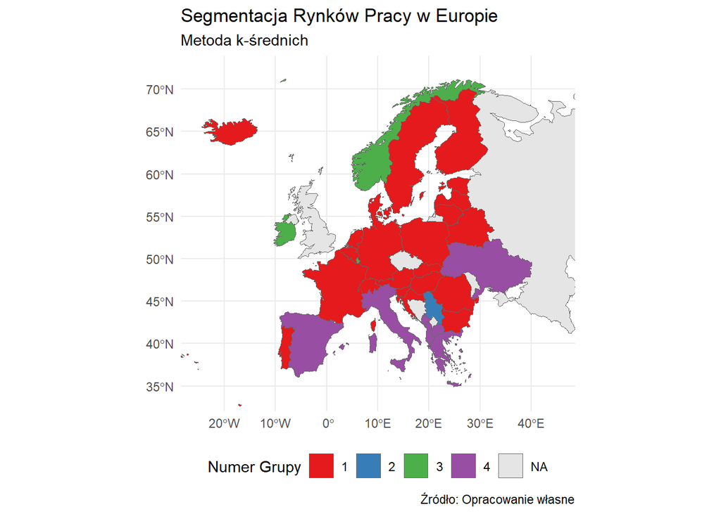

```r
# --- WIZUALIZACJA PRZESTRZENNA KLASTRÓW ---

# 1. Przygotowanie danych do mapy
library(rnaturalearth)
library(stringi)
library(dplyr)
library(ggplot2)

ranking_clusters <- data.frame(
  kraj_clean = tolower(stri_trans_general(df_clean$ref_area, "Latin-ASCII")),
  Cluster = df_clean$Cluster
)

# 2. Pobranie mapy
europe_map <- ne_countries(scale = "medium", returnclass = "sf", continent = "Europe")
europe_map$name_clean <- tolower(stri_trans_general(europe_map$name, "Latin-ASCII"))

# 3. Połączenie
map_data_clust <- europe_map %>%
  left_join(ranking_clusters, by = c("name_clean" = "kraj_clean"))

# 4. Wykres
ggplot(map_data_clust) +
  geom_sf(aes(fill = Cluster), color = "grey40", size = 0.2) +
  scale_fill_brewer(palette = "Set1", name = "Numer Grupy", na.value = "grey90") +
  labs(
    title = "Segmentacja Rynków Pracy w Europie",
    subtitle = "Metoda k-średnich",
    caption = "Źródło: Opracowanie własne"
  ) +
  theme_minimal() +
  coord_sf(xlim = c(-25, 45), ylim = c(34, 72)) +
  theme(legend.position = "bottom")
```